# Age-depth modeling in R

#### Duration of the PETM

Now we extract some durations from the section. The section was subdivided by into multiple intervals, we follow the intervals given by Murphy, Farley, and Zachos (2010)

```r
clay_layer_top = 306.15
base_recovery = 306.4
recovery_1_top = 306.15 # “Shoulder” δ13C inflection point F
recovery_2_top = 304.7 # δ13C inflection point G
recovery_3_top = 304.19 # End of anomalously high carbonate sedimentation
```

We get the durations of the recovery interval by using `get_time`:

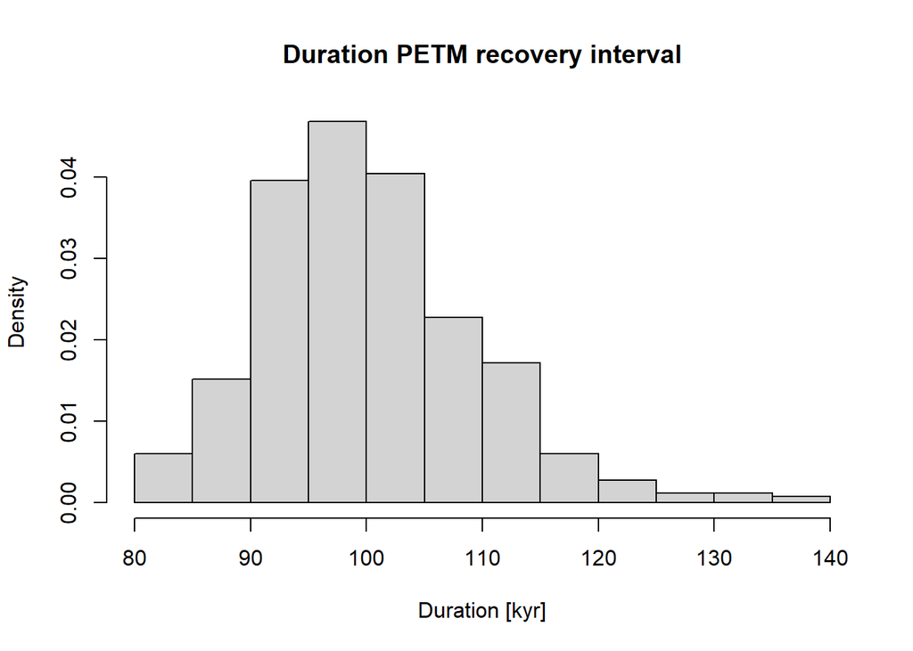

```r
recovery_times = admtools::get_time(adm, h = rev(c(base_recovery, recovery_3_top)))
diff = sapply(recovery_times, diff)
hist(diff,
     main = "Duration PETM recovery interval",
     xlab = "Duration [kyr]",
     freq = FALSE)
```

This gives us a median duration of the PETM recovery interval of 100 kyr at ODP site 1266.

### Tasks

1. What is the duration of the three recovery intervals?
2. Double the assumed 3He flux. How does that change the estimates of the PETM duration?
3. Assume the onset of the clay layer is at exactly 55.9 Ma, with an uncertainty of 0.2 Myr (2 sigma). Add this as a tie point to the analysis, and re-estimate the age-depth model.
4. How does this affect the downstream analyses (e.g., sedimentation rates, median age-depth models, durations)? Which ones are affected, which ones are not? Why?

### Solutions

**TipSolution task 1**

Task: What is the duration of the three recovery intervals?

To calculate the duration of the the three recovery intervals, we reuse the code above and modify the stratigraphic interval examined:

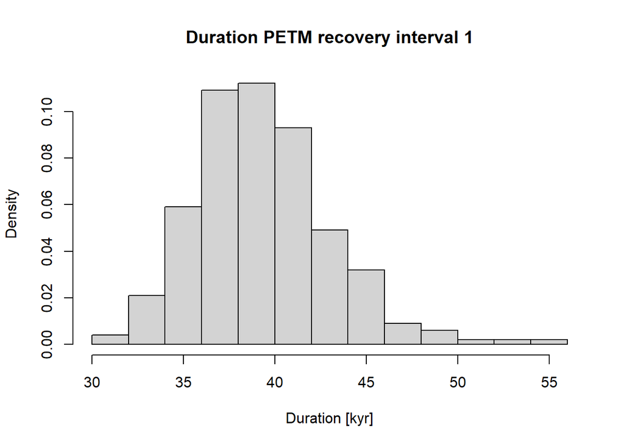

```r
# 1st recover interval
recovery_interval_1 = c(base_recovery, recovery_1_top)
recovery_times = admtools::get_time(adm, h = rev(recovery_interval_1))
diff = sapply(recovery_times, diff)
hist(diff,
     main = "Duration PETM recovery interval 1",
     xlab = "Duration [kyr]",
     freq = FALSE)
```

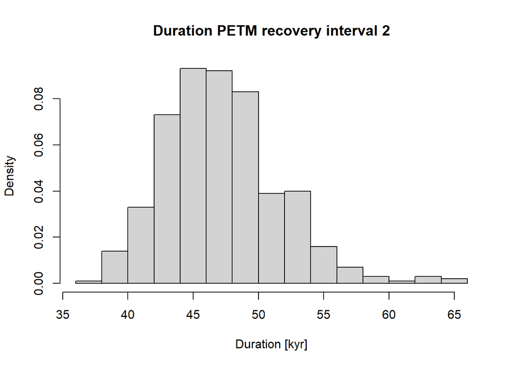

```r
# 2nd recover interval
recovery_interval_2 = c(recovery_1_top, recovery_2_top)
recovery_times = admtools::get_time(adm, h = rev(recovery_interval_2))
diff = sapply(recovery_times, diff)
hist(diff,
     main = "Duration PETM recovery interval 2",
     xlab = "Duration [kyr]",
     freq = FALSE)
```

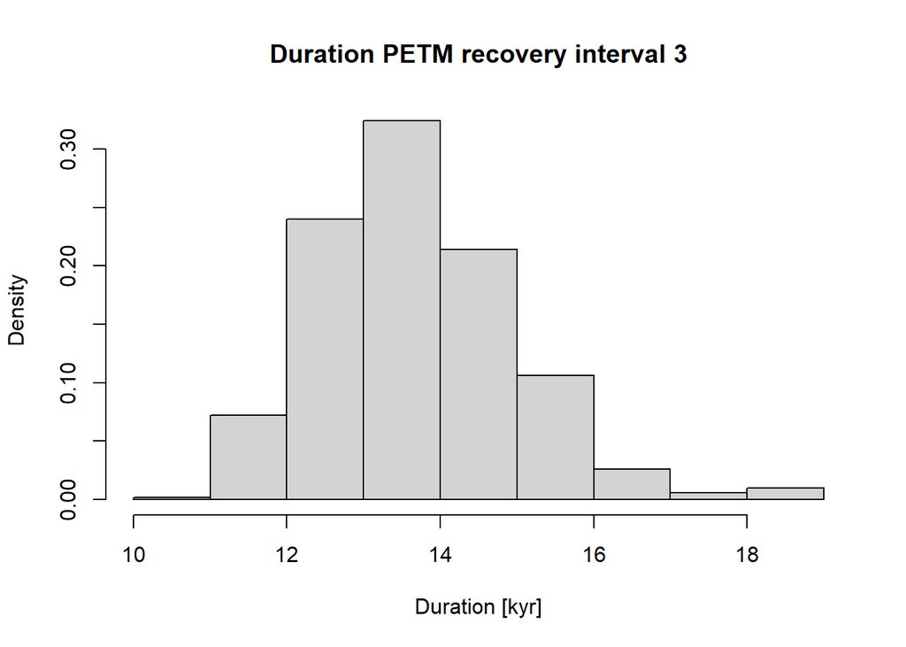

```r
# 3rd recovery interval
recovery_interval_3 = c(recovery_2_top, recovery_3_top)
recovery_times = admtools::get_time(adm, h = rev(recovery_interval_3))
diff = sapply(recovery_times, diff)
hist(diff,
     main = "Duration PETM recovery interval 3",
     xlab = "Duration [kyr]",
     freq = FALSE)
```

**TipSolution task 2**

Task: Double the assumed 3He flux. How does that change the estimates of the PETM duration?

To model this, we multiply the initially modeled 3He flux by 2, and rerun the age-depth model:

```r
double_mean_3He_flux = 2 * mean_3He_flux
time_const_gen_supp_doubled = function(){
  eps = 0.0001
  r = max(eps,rnorm(1, mean = double_mean_3He_flux, sd = twosigma_3H3_flux/2)) # murphy et al 2010, pcc/cm^-2/kyr
  f = approxfun(x = c(-1000, 1000), y = rep(r, 2), rule = 2)
  return(f)
}

adm_doubled_flux = admtools::strat_cont_to_multiadm(h_tp = h_tp,
                               t_tp = t_tp,
                               strat_cont_gen = strat_cont_gen_det,
                               time_cont_gen = time_const_gen_supp_doubled,
                               h = h_est,
                               subdivisions = subdiv,
                               stop.on.error = FALSE,
                               no_of_rep = 500)
```

Plotting it again, it becomes immediately obvious that duration of the covered age-depth model has halved:

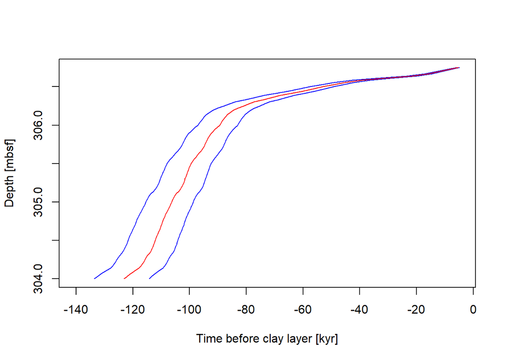

```r
plot(adm_doubled_flux)
mtext("Time before clay layer [kyr]", side = 1, line = 3)
mtext("Depth [mbsf]", side = 2, line = 3)
```

Extracting the durations, we see that the estimated recovery duration has also halved:

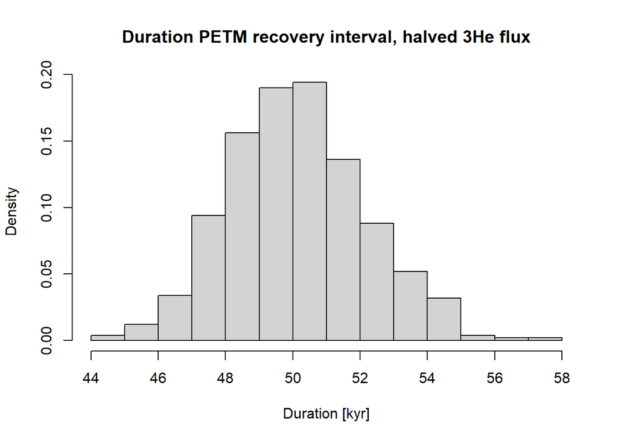

```r
recovery_times = admtools::get_time(adm_doubled_flux, h = rev(c(base_recovery, recovery_3_top)))
diff = sapply(recovery_times, diff)
hist(diff,
     main = "Duration PETM recovery interval, halved 3He flux",
     xlab = "Duration [kyr]",
     freq = FALSE)
```

**TipSolution task 3**

Task: Assume the onset of the clay layer is at exactly 55.9 Ma, with an uncertainty of 0.2 Myr (2 sigma). Add this as a tie point to the analysis, and re-estimate the age-depth model.

For this, we modify the tie point age to match the age assumptions:

```r
t_tp_mod = function(){
  x = rnorm(1, mean = -55900, sd = 100) # unit conversion into kyr & 1 sigma!
  return(x)
}
```

Now we can re-estimate the age-depth model

```r
# height where the adm is estimated
h_est = seq(304, base_clay, by = 0.05)
subdiv = 1000 # numeric options for integration
adm_t_tp_mod = admtools::strat_cont_to_multiadm(h_tp = h_tp,
                               t_tp = t_tp_mod,
                               strat_cont_gen = strat_cont_gen_det,
                               time_cont_gen = time_const_gen_supp,
                               h = h_est,
                               subdivisions = subdiv,
                               stop.on.error = FALSE,
                               no_of_rep = 500)
```

and plot it:

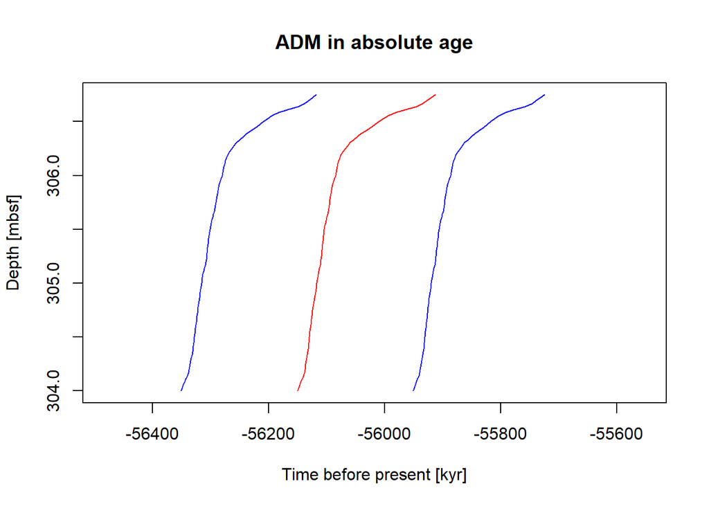

```r
plot(adm_t_tp_mod)
mtext("Time before present [kyr]", side = 1, line = 3)
mtext("Depth [mbsf]", side = 2, line = 3)
title(main = "ADM in absolute age")
```

Not the high uncertainty in the age-depth model now. This uncertainty is dominated by the uncertainty at the tie point rather the uncertainty introduced by the 3He measurements or the fluctuations in 3He flux. However, calculating the duration of the PETM recovery interval shows that it remains identical: The uncertainty of the tie point does not propagate into durations.

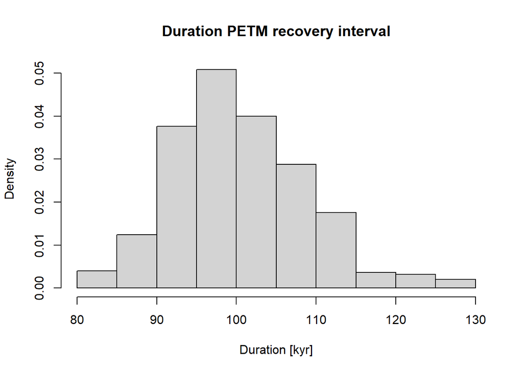

```r
recovery_times = admtools::get_time(adm_t_tp_mod, h = rev(c(base_recovery, recovery_3_top)))
diff = sapply(recovery_times, diff)
hist(diff,
     main = "Duration PETM recovery interval",
     xlab = "Duration [kyr]",
     freq = FALSE)
```

**TipSolution task 4**

Task: How does this affect the downstream analyses (e.g., sedimentation rates, median age-depth models, durations)? Which ones are affected, which ones are not? Why?

The uncertainty of the tie point only matters for the absolute age of events, e.g., when the second recovery interval started.

The median age-depth model is only shifted by the median absolute age, and all analyses that are based on durations (e.g., duration of the recovery intervals) are not affected because the uncertainty of the tie point cancels out.

## References

Da Silva, Anne-Christine. 2024. *Anchoring the Late Devonian Mass Extinction in Absolute Time by Integrating Climatic Controls and Radio-Isotopic Dating: Supplementary Code*. Zenodo. https://doi.org/10.5281/ZENODO.12516430.

Da Silva, Anne-Christine, Matthias Sinnesael, Philippe Claeys, Joshua H. F. L. Davies, Niels J. de Winter, L. M. E. Percival, Urs Schaltegger, and David De Vleeschouwer. 2020. “Anchoring the Late Devonian Mass Extinction in Absolute Time by Integrating Climatic Controls and Radio-Isotopic Dating.” *Scientific Reports* 10 (1): 12940. https://doi.org/10.1038/s41598-020-69097-6.

De Vleeschouwer, David, and Christian Zeeden. 2021. “Age Models and Geochronology: An Introduction to Different Age-Depth Modelling Approaches.” Zenodo. https://doi.org/10.5281/zenodo.4749027.

Hohmann, N., D. De Vleeschouwer, S. Batenburg, and E. Jarochowska. 2024. “Nonparametric Estimation of Age-Depth Models from Sedimentological and Stratigraphic Information.” *EGUsphere* 2024: 1–31. https://doi.org/10.5194/egusphere-2024-2857.

Hohmann, Niklas, and Emilia Jarochowska. 2025a. “StratPal: An r Package for Creating Stratigraphic Paleobiology Modelling Pipelines.” *Methods in Ecology and Evolution* 16 (4): 678–86. https://doi.org/https://doi.org/10.1111/2041-210X.14507.

———. 2025b. “Supplementary Data and Code for "Nonparametric Estimation of Age-Depth Models from Sedimentological and Stratigraphic Data".” Zenodo. https://doi.org/10.5281/zenodo.15489276.

Meyers, Stephen R. 2019. “Cyclostratigraphy and the Problem of Astrochronologic Testing.” *Earth-Science Reviews* 190 (March): 190223. https://doi.org/10.1016/j.earscirev.2018.11.015.

Murphy, B. H., K. A. Farley, and J. C. Zachos. 2010. “An Extraterrestrial 3He-Based Timescale for the Paleocene–Eocene Thermal Maximum (PETM) from Walvis Ridge, IODP Site 1266.” *Geochimica Et Cosmochimica Acta* 74 (17): 5098–108. https://doi.org/https://doi.org/10.1016/j.gca.2010.03.039.

Parnell, A. C., J. Haslett, J. R. M. Allen, C. E. Buck, and B. Huntley. 2008. “A Flexible Approach to Assessing Synchroneity of Past Events Using Bayesian Reconstructions of Sedimentation History.” *Quaternary Science Reviews* 27 (19): 18721885. https://doi.org/10.1016/j.quascirev.2008.07.009.

Percival, L. M. E., J. H. F. L. Davies, U. Schaltegger, D. De Vleeschouwer, A.-C. Da Silva, and K. B. Föllmi. 2018. “Precisely Dating the FrasnianFamennian Boundary: Implications for the Cause of the Late Devonian Mass Extinction.” *Scientific Reports* 8 (1): 9578. https://doi.org/10.1038/s41598-018-27847-7.

Sinnesael, Matthias, David De Vleeschouwer, Christian Zeeden, Sietske J. Batenburg, Anne-Christine Da Silva, Niels J. de Winter, Jaume Dinarès-Turell, et al. 2019. “The Cyclostratigraphy Intercomparison Project (CIP): Consistency, Merits and Pitfalls.” *Earth-Science Reviews* 199: 102965. https://doi.org/https://doi.org/10.1016/j.earscirev.2019.102965.

Trayler, Robin B., Stephen R. Meyers, Bradley B. Sageman, and Mark D. Schmitz. 2023. “Bayesian Integration of Astrochronology and Radioisotope Geochronology.” https://doi.org/10.5194/gchron-2023-22.

Trayler, Robin B., Mark D. Schmitz, José I. Cuitiño, Matthew J. Kohn, M. Susana Bargo, Richard F. Kay, Caroline A. E. Strömberg, and Sergio F. Vizcaíno. 2019. “An Improved Approach to Age-Modeling in Deep Time: Implications for the Santa Cruz Formation, Argentina.” *GSA Bulletin* 132 (1-2): 233–44. https://doi.org/10.1130/B35203.1.